# FigureYa27t-SNE_update

## 按照其他元信息的列进行着色。

按照个体着色，查看来源于三个人的细胞的分布情况

```
## The following functions and any applicable methods accept the dots: CombinePlots
```

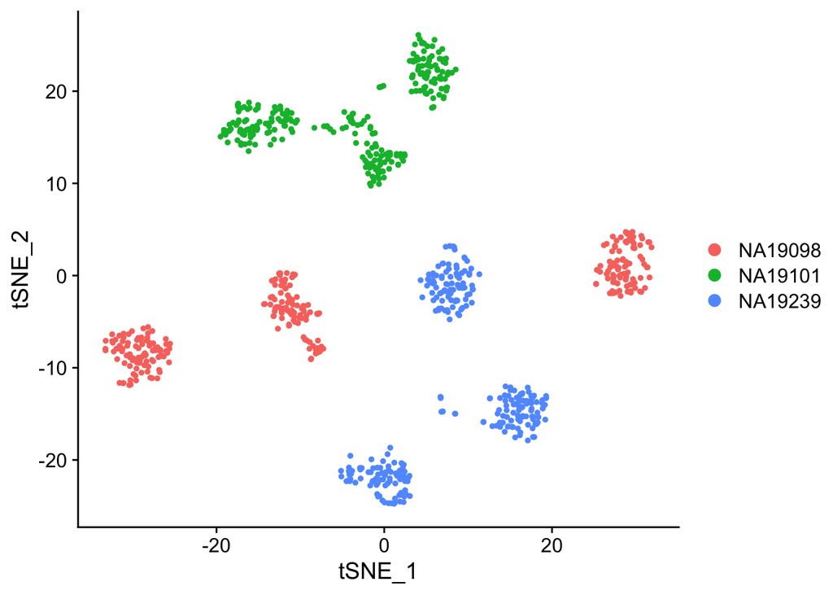

```r
DimPlot(obj, reduction.use = "tsne",
        cols.use = mycol,
        group.by = "individual")
```

# 输出分类信息

## 输出marker基因

获取每个分类的可能标记基因(候选分子标记)

```r
markers <- FindAllMarkers(obj,
                         test.use = "wilcox",
                         min.pct = 0.1,
                         min.diff.pct = -Inf)
write.csv(markers, file="cell_type_markers.csv",quote = FALSE,
          row.names = TRUE)
```

## 展示候选marker基因的表达量

可以画一个基因，也可以同时画多个基因

通常会用候选marker基因画图，参考例图paper里的`Extended Data Figure 8d`

从上一部分“输出marker基因”输出的`cell_type_markers.csv`文件里选出每类`p_val_adj`排名第一的基因，例如第II类(class为1)的`ENSG00000205364`。

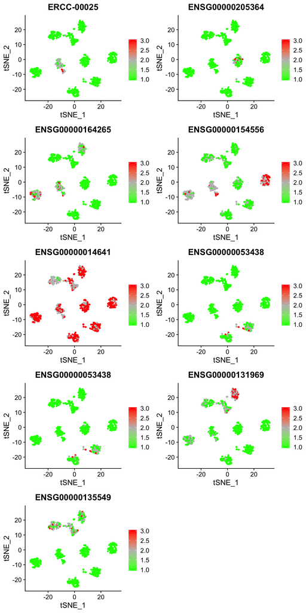

```r
FeaturePlot(obj, reduction = "tsne",
            features = c("ERCC-00025","ENSG00000205364","ENSG00000164265","ENSG00000154556","ENSG00000014641","ENSG00000053438","ENSG00000053438","ENSG00000131969","ENSG00000135549"),
            ncol  = 2, #画在2列里
            cols = c("green","grey","red"), #用三种颜色，分别展示低表达、中表达和高表达
            #do.return =T, #返回ggplot2对象，便于组图
            #no.legend = F, #显示图例
            pt.size = 1
            )
```

```r
ggsave("marker.pdf")
```

## 输出分类信息及表达矩阵

可用于下一步分析、作图：

- 后续应用一：像例图paper的Figure4c那样，用各组样品ID提取临床信息和高频突变基因，绘制瀑布图oncoprint，见`FigureYa18 oncoprint`；
- 后续应用二：用各组候选marker基因表达矩阵画heatmap，见`FigureYa17 heatmap`。

```r
cell_type_df <- as.data.frame(obj$seurat_clusters)
colnames(cell_type_df) <- "CellType"
cell_type_df <- cbind(cell_type_df, t(obj@assays$RNA@scale.data))
write.csv(t(cell_type_df),"molecules_in_cell_types.csv")
```